# Reproducible Research Week 2 Course Project 1

Author: Tumisang Liphoto

Date: 12/13/2021

## R Markdown

This is an R markdown file that presents the solutions to the questions asked in the Reproducible Research Week 2 Course Project 1. The data used used in this solution is downloaded from [this](https://d396qusza40orc.cloudfront.net/repdata%2Fdata%2Factivity.zip) address on 12/13/2021.

1. Loading and pre-processing the data.
2. Histogram of the total number of steps taken each day
3. Calculate and report the mean and median of the total number of steps taken per day.
4. Create a time series plot of the data.
5. Finding 5-minute interval that, on average, contains the maximum number of steps
6. Imputting missing values
   1. Strategy for filling in all of the missing values.
   2. Create new dataset without missing values.
   3. Make a histogram of the total number of steps taken each day and Calculate and report the mean and median total number of steps taken per day
   1. Do these values differ from the estimates from the first part of the assignment?
   2. What is the impact of imputing missing data on the estimates of the total daily number of steps?

# 1. Loading and Preprocessing Data

```r
library(data.table)
library(dplyr)#load dplyr
```

```r
library(ggplot2)#load ggplot2
library(magrittr)

dataFile <- "Reproducible_Research _Week2_Peer_Review"

if (!file.exists(dataFile)){
  fileURL <- "https://d396qusza40orc.cloudfront.net/repdata%2Fdata%2Factivity.zip"
  print("downloading....")
  download.file(fileURL, destfile = dataFile, method="curl")
  print("done download")
  print("unzipping")
  unzip (zipfile = dataFile)
  print("done unzipping")
}

activitydata <- read.csv("activity.csv", header = TRUE)
head(activitydata)
```

```
##   steps       date interval
## 1    NA 2012-10-01        0
## 2    NA 2012-10-01        5
## 3    NA 2012-10-01       10
## 4    NA 2012-10-01       15
## 5    NA 2012-10-01       20
## 6    NA 2012-10-01       25
```

```r
  summary(activitydata)
```

```
##      steps            date              interval
##  Min.   :  0.00   Length:17568       Min.   :   0.0
##  1st Qu.:  0.00   Class :character   1st Qu.: 588.8
##  Median :  0.00   Mode  :character   Median :1177.5
##  Mean   : 37.38                      Mean   :1177.5
##  3rd Qu.: 12.00                      3rd Qu.:1766.2
##  Max.   :806.00                      Max.   :2355.0
##  NA's   :2304
```

# 2. Histogram of the total number of steps taken each day

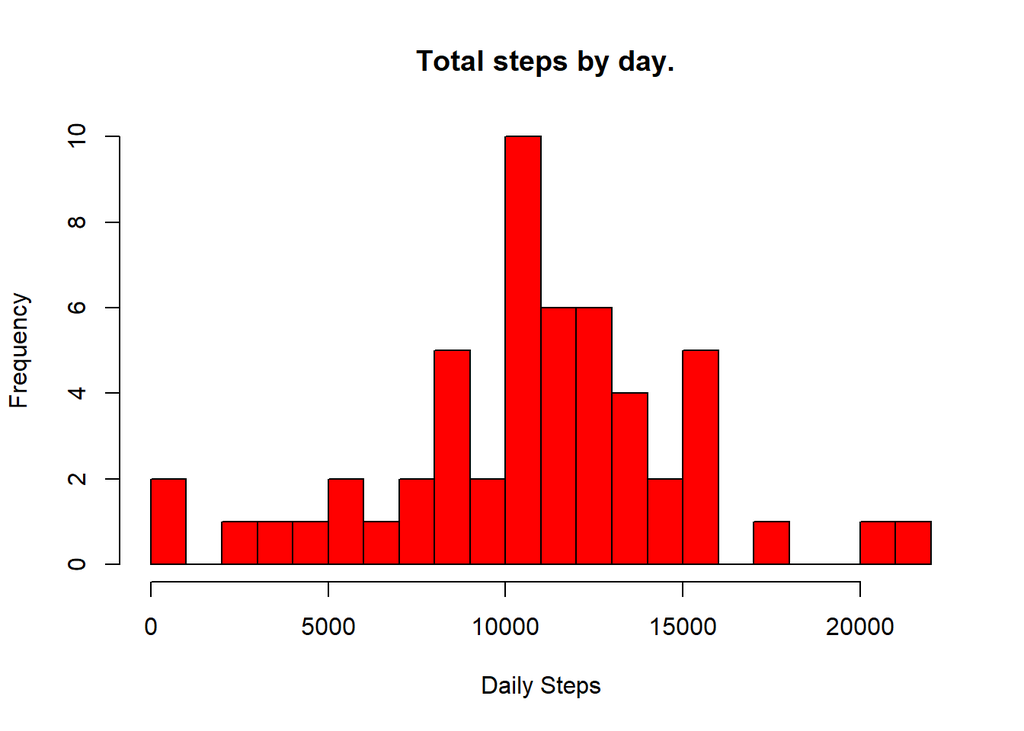

```r
dailyData <- activitydata %>% select(date, steps) %>% group_by(date) %>% summarize(totalSteps= sum(steps)) %>%na.omit()

hist(dailyData$totalSteps, xlab = "Daily Steps",main=" Total steps by day.", breaks = 20, col = "red")
```